# Impact and Analysis of Weather Events

#### 5.What is the total number of casualties (injuries and deaths ) in 2016 by each events?

Here we have considered top 10 events on the basis of injuries and deaths and eventaully casualties. Injuries is considered as sum of direct and indirect injuries in data and deaths is considered combining direct and indirect death columns of data. Casualties is calculated adding up both injuries and casualties.

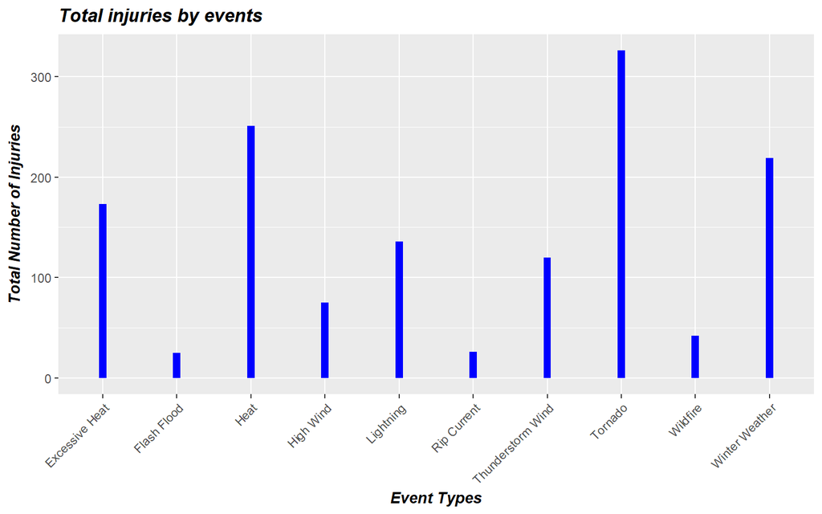

```r
Dataset4_na_addcol$TOTAL_INJURIES <- (Dataset4_na_addcol$INJURIES_DIRECT + Dataset4_na_addcol$INJURIES_INDIRECT)

Dataset4_na_addcol$TOTAL_DEATHS <- (Dataset4_na_addcol$DEATHS_DIRECT + Dataset4_na_addcol$DEATHS_INDIRECT)

Dataset4_na_addcol$TOTAL_CASUALTIES <- (Dataset4_na_addcol$TOTAL_INJURIES + Dataset4_na_addcol$TOTAL_DEATHS)

# topten events for each case
Injuries <- aggregate(cbind(INJURIES_DIRECT,INJURIES_INDIRECT,TOTAL_INJURIES) ~ EVENT_TYPE, data = Dataset4_na_addcol, FUN = sum )

Deaths <- aggregate(cbind(DEATHS_DIRECT,DEATHS_INDIRECT,TOTAL_DEATHS) ~ EVENT_TYPE, data = Dataset4_na_addcol, FUN = sum)

Casualties <- aggregate(cbind(TOTAL_INJURIES,TOTAL_DEATHS,TOTAL_CASUALTIES) ~ EVENT_TYPE, data = Dataset4_na_addcol, FUN = sum)

totalInjuries <- Injuries[order(Injuries$TOTAL_INJURIES, decreasing = T), ]
topTen_totalInjuries <- totalInjuries[1:10, ]

totalDeaths <- Deaths[order(Deaths$TOTAL_DEATHS, decreasing = T), ]
topTen_totalDeaths <- totalDeaths[1:10, ]

totalCasualties <- Casualties[order(Casualties$TOTAL_CASUALTIES, decreasing = T), ]
topTen_totalCasualties <- totalCasualties[1:10, ]

# Plots
#plot for injuries

p4 <- ggplot(topTen_totalInjuries, aes(x=EVENT_TYPE, y = TOTAL_INJURIES))+geom_bar(stat = "identity", width = 0.1, fill = "blue")

p4+ theme(axis.text.x = element_text(angle = 45, hjust =1),
          title = black.bold.italic.text, axis.title = black.bold.italic.text)+
  labs(title = "Total injuries by events",
       x="Event Types", y="Total Number of Injuries")
```

In above graph, Torando is the most devastating event causing injuries in 2016

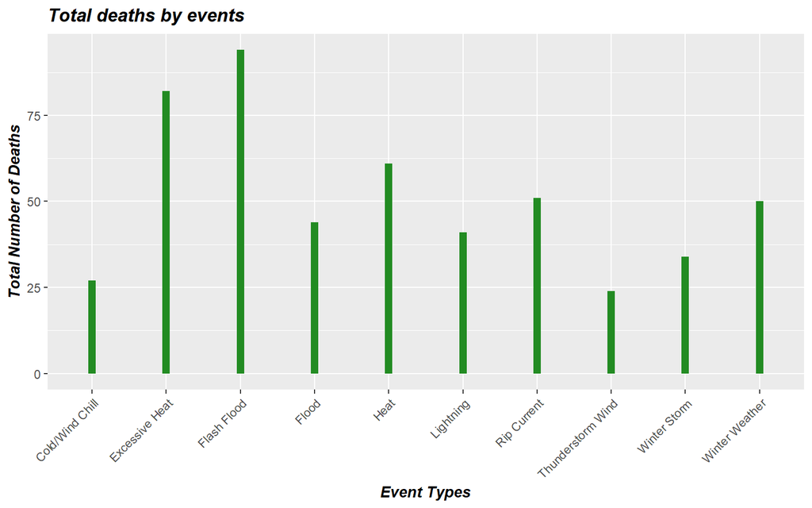

```r
#plot for Deaths


p5 <- ggplot(topTen_totalDeaths, aes(x=EVENT_TYPE, y = TOTAL_DEATHS))+geom_bar(stat = "identity", width = 0.1, fill = "forestgreen")

p5+ theme(axis.text.x = element_text(angle = 45, hjust =1),
          title = black.bold.italic.text, axis.title = black.bold.italic.text)+
  labs(title = "Total deaths by events",
       x="Event Types", y="Total Number of Deaths")
```

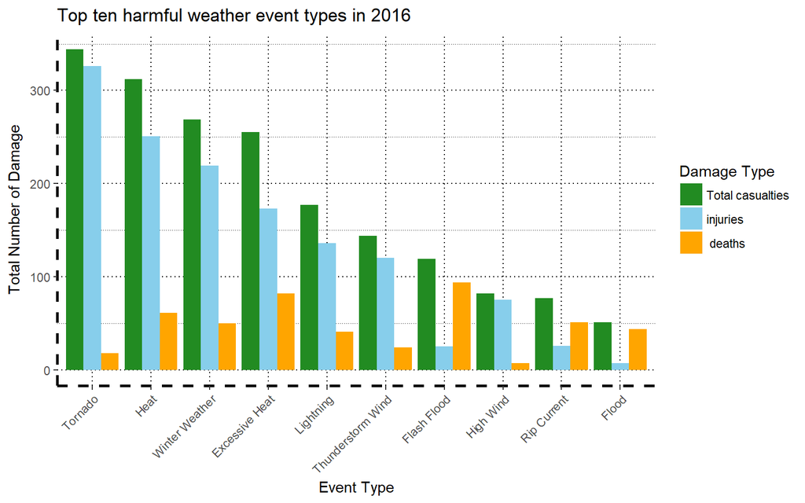

```r
#plot for Total Casualties

p6 <- melt(topTen_totalCasualties[, c("EVENT_TYPE", "TOTAL_CASUALTIES", "TOTAL_INJURIES", "TOTAL_DEATHS")], id.vars = 1)

ggplot(p6, aes(x = reorder(EVENT_TYPE, -value), y = value)) + geom_bar(stat = "identity", aes(fill = variable), position = "dodge")+scale_y_continuous(labels = comma)+ theme(axis.text.x = element_text(angle = 45, hjust = 1), axis.line = element_line(size = 1, colour = "black", linetype = "dashed"),
                                                                                                                                                                              panel.background = element_rect(fill = "white"), panel.grid.major = element_line(colour = "black", linetype = "dotted"),
                                                                                                                                                                              panel.grid.minor = element_line(colour = "black", linetype = "dotted")) + xlab("Event Type") + ylab("Total Number of Damage") + ggtitle("Top ten harmful weather event types in 2016") +
  scale_fill_manual(name = "Damage Type", values = c("forestgreen", "skyblue", "orange"),
                    labels = c("Total casualties",  "injuries", " deaths"))
```

Above graph shows the total casualties considering deaths and injuries above. We can see that some event like tornado has more injuries than deaths while events like flash flood, rip current and flood are causing more deaths than injuries.